# Generalized Linear Mixed Models

An Analysis on National Maternal Mortality

Author

Carolyn Herrera & Catherine Funte (Advisor: Dr. Cohen)

Published

August 8, 2025

Slides: slides.html ( Go to `slides.qmd` to edit)

## Introduction

Generalized Linear Mixed Models (GLMMs) are a flexible class of statistical models that combine the strengths of two powerful frameworks: Generalized Linear Models (GLMs) and Mixed-Effects Models (Agresti 2015). Like GLMs, GLMMs can model non-normal outcome variables, such as binary, count, or proportion data. However, extend GLMs by incorporating random effects, which account for variability due to grouping or clustering, correlated observations, and overdispersion. This makes GLMMs well-suited for complex data structures involving temporal or spatial correlation, nested hierarchies, heterogeneity of variance, and repeated measurements (Zuur et al. 2009).

In practice, GLMMs are especially useful when data points are not independent—for example, when students are nested within schools, patients are treated within hospitals, or repeated measures are taken from the same subject over time. Thall (Thall 1988) noted that longitudinal clinical trials often struggle to determine whether observed changes in outcomes are attributable to treatment effects or simply the passage of time. This ambiguity makes it difficult to compare outcomes between subjects. GLMMs address this by modeling for within-subject dependence, incorporating covariates, treating time as a function, capturing variability between patients, and provides both flexibility and tractability. The random effects help model the correlation within clusters and allow for unobserved heterogeneity—differences that are not captured by the measured covariates.

GLMMs are good for:

- Handling hierarchical or grouped data (e.g., students within classrooms, patients within clinics) (Lee and Nelder 1996)
- Modeling non-normal outcomes, such as:
  - Binary outcomes (using logistic GLMMs) (Wang et al. 2017)
  - Count data (using Poisson or negative binomial GLMMs) (Candy 2000)
  - Proportions or rates (Salinas Ruı́z et al. 2023)
- Reducing bias and inflated Type I error rates that can result from ignoring data structure (Thompson et al. 2022)

GLMMs are ideal for analyzing complex data structures that involve non-Gaussian response variables, making them indispensable in fields like medicine, ecology, education, and social sciences. For example, Tawiah et al. (Tawiah, Iddi, and Lotsi 2020) describe zero-inflated Poisson GLMMs—an extension of Poisson GLMM that allows for overdispersion due to a prevalence of zeros in the data, common in health sector data . The paper compares four models: a Poisson GLM, a zero-inflated Poisson GLM, a Poisson GLMM, and a zero-inflated Poisson GLMM, applied to clustered maternal mortality data.The study found the zero-inflated Poisson GLMM to yield to best results. Similarly, Owili et al. (Owili et al. 2020) utilize a GLMM with Poisson link function to investigate the impact of particulate matter on maternal and infant mortality globally and regionally. In their global analysis, year and country are modeled as random effects to account for variation in regional data.

This study investigates the potential risks faced by mothers in a post-Roe v. Wade context, with a particular focus on the systemic disparities that continue to affect women of color during childbirth(Compton and Greer 2022),(Tran et al. 2023). To analyze these risks, we will apply a Generalized Linear Mixed Model (GLMM), a robust statistical method suited for complex, hierarchical data. Our goal is to examine the relationship between maternal mortality and key explanatory variables, including age group, ethnicity, and whether the death occurred during the post-Dobbs era. These findings are especially relevant as they may provide evidence to inform public health interventions aimed at reducing maternal mortality among vulnerable populations, and to assess whether the legal and healthcare shifts following the Dobbs v. Jackson Women’s Health Organization decision have contributed to an increase in maternal deaths.

## Methods

#### Math Background

GLMMs extends GLMs, by including random effects to account for correlation and variability within clustered or repeated observations. GLMMs can also be viewed as an extension of Linear Mixed Models (LMMs), which are adapted for non-Gaussian outcome distributions (Salinas Ruı́z et al. 2023).

Let

- $\mathbf{y}$ be a $Nx1$ column vector outcome variable
- $\mathbf{X}$ be a $Nxp$ matrix for the $p$ predictor variables
- $\boldsymbol{\beta}$ be a $px1$ column vector of the fixed effects coefficients
- $\mathbf{Z}$ is a $Nxq$ matrix of the $q$ random effects
- $\mathbf{u}$ is a $qx1$ vector of random effects, and
- $\boldsymbol{\epsilon}$ is a $Nx1$ column vector of the residuals

Then the general equation for the model is given by:

$$\mathbf{y}=\mathbf{X}\boldsymbol{\beta}+\mathbf{Z}{u}+\boldsymbol{\epsilon}$$
(Salinas Ruı́z et al. 2023). In GLMMs, the response variable $\mathbf{y}$ is assumes to follow a distribution from the exponential family. The model introduces a linear predictor, $\eta$, defined as:
$$\boldsymbol{\eta}=\mathbf{X}\boldsymbol{\beta}+\mathbf{Z}\boldsymbol{\lambda}$$
A link function relates the expected value of the response variable to this linear predictor:
$$g(E(\mathbf{y}))=\boldsymbol{\eta}$$
The choice of link function depends on the distribution of the outcome variable. In this study, the data is overdispersed counts, which makes the Negative Binomial distribution appropriate. Therefore, we will use a log link function.
$$g(\cdot)=log_e(\cdot)$$
Parameter estimation in GLMMs involves maximizing the log-likelihood or minimizing the negative log-likelihood (Salinas Ruı́z et al. 2023). Model-derived quantities such as estimated means or least-squares means are initially computed on the model scale and can then be back-transformed to the data scale using the inverse of the link function.

The Negative Binomial Distribution is defined as:
$$f(y;k,{\mu})=\frac{\Gamma(y+k)}{\Gamma(k)*(y+1)}\left(\frac{k}{\mu+k}\right)^{k}\left(1-\frac{k}{\mu+k}\right)^{y}$$
where:

- $\mu$ is the mean of the distribution,
- $k$ is the dispersion parameter, and
- $\Gamma(\cdot)$ is the gamma function, where $\Gamma(y+1)=y!$

The mean and variance are:

- $E(Y) = \mu$
- $\text{Var}(Y) = \mu + \frac{\mu^2}{k}$

The dispersion parameter $k$ controls the degree of overdispersion. As $k \to \infty$, the variance approaches the mean, and the Negative Binomial converges to the Poisson distribution. However, when $k$ is small, the variance increases, indicating significant overdispersion, making the Negative Binomial distribution preferable to Poisson in such cases (Zuur et al. 2009).

#### Assumptions

Before deciding to use a GLMM for our data, we had to check some assumptions (specific to our Negative Binomial distributed data).

- The response variable and the predictors have a linear relationship within the levels of random effects.
- The response variable is assumed to follow a negative binomial distribution, with $\sigma^2>\mu$.
- The residuals and random effects are independent.
- The random effects are assumed to be normally distributed, with mean 0 and variance $\sigma$.

#### Model Selection and Implementation

The quadratic nature of the Negative Binomial distribution’s mean-variance relationship is ideal for overdispersed count data that the Poisson distribution cannot accommodate. Overdispersion is a given for populations due to their heterogeneity that aggregation processes such as community clusters form with shared traits such as ethnicity. Our data includes community cluster groups such as ethnicity and age groups. The negative binomial model is desirable also due to its easily interpretable dispersion parameter as a measure of aggregation and its tractability due to closed form expression of probability mass function which helps in convenient model inference and estimation. Since our data is longitudinal, a Negative Binomial GLMM is ideal since measurements are taken over time. We incorporate Year as a random effect because it could explain for variation in our model which could not be explained by our fixed effects such as ethnicity or age group.

We conduct our analyses in R (R Core Team 2019), using the following packages and functions for modeling:

- `lme4` (Bates et al. 2015):
  - `glmer()` for Poisson GLMMs
- `glmmTMB` (McGillycuddy et al. 2025):
  - `glmmTMB(..., family = nbinom2)` for Negative Binomial GLMMs

Each function employs different methods for parameter estimation:

- `glmmTMB` uses Adaptive Gauss-Hermite Quadrature (AGQ) or Laplace approximation, along with Wald Z-tests for fixed-effect significance (McGillycuddy et al. 2025).
- `lme4` defaults to the Laplace approximation for log-likelihood estimation and can also use Gauss-Hermite quadrature for more precise estimation but reduced speed (Bates et al. 2015).

Densities, such as maternal deaths per number of live births, can be modeled using count data with an offset variable (Zuur et al. 2009). While maternal mortality rate could be modeled directly, using an offset, specifically log(Live Births), enables more stable and interpretable modeling of raw counts.

We plan to compare models both with and without the offset term, evaluating them using the Akaike Information Criterion (AIC). The model with the lower AIC is preferred, as it balances goodness of fit with model complexity.

The selection of fixed vs. random effects in our models depend on the specific research question.

Random effects may include:

- Year
- Month
- Nested terms such as Month/Year

Fixed effects may include:

- Age group
- Ethnicity
- Year (if not treated as random)
- Dobbs Era (pre- or post-)

Offset:

- Log(Live Births)

## Analysis and Results

### Data Exploration and Visualization

The data we used come from the National Vital Statistics System, an organization that provides national data about births, deaths, marriages, divorces, and fetal deaths. It is a collaboration between the National Center for Health Statistics (NCHS) (a part of the CDC) and state vital records offices. (2016) This dataset is the Vital Statistics Rapid Release (VSRR) Provisional Maternal Death Counts and Rates, in the form of a .csv file. The dataset contains monthly death counts and death rates from 2019 to 2024 by race and ethnicity, age and overall. Rates are maternal deaths per 100,000 live births. For this dataset, a maternal death is defined as “the death of a woman while pregnant or within 42 days of termination of pregnancy irrespective of the duration and the site of the pregnancy, from any cause related to or aggravated by the pregnancy or its management, but not from accidental or incidental causes.” (2025). It is worth noting that this dataset is provisional, in that the data is updated quarterly as more data is received, and data from numbers from previous years is more reliable than numbers from recent years. The data was last updated April 6, 2025.

```r
# loading packages
library(tidyverse)
library(knitr)
library(ggthemes)
library(ggrepel)
library(dslabs)
library(ggplot2)
library(patchwork) # For combining plots
library(ggpubr)
library(DataExplorer) #For EDA
options(repos = c(CRAN = "https://cloud.r-project.org"))#specify cran mirror
if (!require("lme4")) install.packages("lme4")#if required to install
library(lme4)
##to check if model is overdispersed'
if (!require("performance")) install.packages("performance")#if required to install
library(performance)
##Overdispersion is detected with Poisson model thus we must use negative binomial model
if (!require("glmmTMB")) install.packages("glmmTMB")#if required to install
library(glmmTMB)
if (!require("ggeffects")) install.packages("ggeffects")
library(ggeffects)
if (!require("AICcmodavg")) install.packages("AICcmodavg")
library(AICcmodavg)
```

```r
df <- read.csv("data/VSRR_Provisional_Maternal_Death_Counts_and_Rates_20250726.csv")#loading data
#variables- Maternal.Deaths--outcome variable
#Live.Births---offset variable since it is maternal deaths per live births
#Subgroup- ethnicity and year of mother must be edited --- these are fixed
#Year.of.Death---random effect variable
#Summary
#renaming columns
df<-df%>%
  rename(Year= Year.of.Death, Month= Month.of.Death, Maternal_Deaths= Maternal.Deaths, Live_Births= Live.Births, Maternal_Mortality_Rate= Maternal.Mortality.Rate, Time_Period= Time.Period, Month_Ending_Date= Month.Ending.Date, Data_As_Of= Data.As.Of)

filtered_df<- df%>% filter(Maternal_Deaths > 0, Live_Births > 100) #Filtering out potential stange data

test_df <- na.omit(filtered_df)#filtered na
```

```r
#Summary Statistics

deaths_df <-test_df %>%
  mutate(
    Ethnicity = case_when(
      Group == "Race and Hispanic origin" ~ Subgroup,
      TRUE ~ NA_character_
    ),
    Age_Group = case_when(
      Group == "Age" ~ Subgroup,
      TRUE ~ NA_character_
    ),
    Is_Total = Subgroup == "Total"
  ,
  Year = as.factor(Year),
  Month= as.factor(Month),
  Ethnicity=as.factor(Ethnicity),
  Age_Group=as.factor(Age_Group))#mutating groups

deaths_df_ethnic<-deaths_df %>%
  filter(!is.na(Ethnicity))%>%
  mutate(Ethnicity = Subgroup)###filter out is total if ethnicity or age group are na

deaths_df_age <-deaths_df %>%
  filter(!is.na(Age_Group)) %>%
  mutate(Age_Group = Subgroup)


merged_deaths_df <-  bind_rows(deaths_df_ethnic, deaths_df_age)  #merge both df

#setting factor levels
deaths_df3 <- merged_deaths_df %>%
  mutate(
    Ethnicity = factor(Ethnicity, levels = c(
      "Asian, Non-Hispanic", "Black, Non-Hispanic", "White, Non-Hispanic",
      "Hispanic", "American Indian or Alaska Native, Non-Hispanic",
      "Native Hawaiian or Other Pacific Islander, Non-Hispanic", "Unknown"
    )),
    Age_Group = factor(Age_Group, levels = c("Under 25 years", "25-39 years", "40 years and over", "Unknown"))
  )

#mutating any NAs with unknown
deaths_df3<- deaths_df3 %>%
   mutate(
    Ethnicity = replace_na(Ethnicity, "Unknown"),
    Age_Group = replace_na(Age_Group, "Unknown")
  )

# make variable in which we combine Year and Month into a for of a date to create later variable, or use month ending date?
deaths_df3$Date <- as.Date(paste(deaths_df3$Year, deaths_df3$Month, "01", sep = "-"))

# Dobbs was decided June 24, 2022
cutoff <- as.Date("2022-06-24")##when Roe v.Wade was overturned

deaths_df3$Dobbs_Era <- ifelse(deaths_df3$Date < cutoff, "Pre-Dobbs", "Post-Dobbs")
deaths_df3$Dobbs_Era <- factor(deaths_df3$Dobbs_Era, levels = c("Pre-Dobbs", "Post-Dobbs"))

df_age_year <- deaths_df %>%
  filter(!is.na(Age_Group), !is.na(Year)) %>%
  group_by(Year, Age_Group) %>%
  summarise(Maternal_Deaths = sum(Maternal_Deaths, na.rm = TRUE))
#df_age_year

df_total_year <-deaths_df%>%
  filter(Group=="Total") %>%
  group_by(Year, Is_Total) %>%
  summarise(Maternal_Deaths = sum(Maternal_Deaths, na.rm = TRUE))
#df_total_year
```

The below chart gives an idea of the missing values in the dataset. It seems like there are many NAs in ethnicity and age group, certainly more than is acceptable. The dataset indicates that Maternal Deaths between 1 and 9 are suppressed for privacy reasons. With more investigation, it appears that the racial/ethnic group “Native Hawaiian or Other Pacific Islander, Non-Hispanic” has NA for 70 (all but 2) Maternal Deaths values. We decided to omit this subgroup entirely. There are 58 missing Maternal Mortality Rate entries in “American Indian or Alaska Native, Non-Hispanic”, which will not be an issue as we are not using rate explicitly in our model (though we will examine it during our Exploratory Data Analysis). Finally, there are seven NA Maternal Deaths also in the “American Indian or Alaska Native, Non-Hispanic” category, a number that is reasonable to omit.

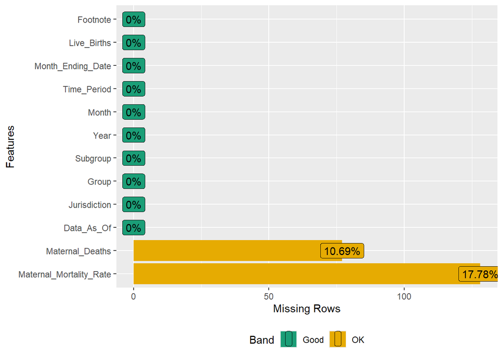

```r
plot_missing(df)
```

Since our data is longitudinal, it is easy to visualize with graphs. Below is a bar chart that shows the distribution of Maternal Deaths by racial/ethnic group. The counts indicated the sum of the Maternal Deaths for each group over the span of the data (2019-2024). Since these are sums of maternal death counts, they are reflective of the relative population of each group. Namely, white women had the largest number of deaths as they are the largest population, and American Indian or Alaska Native had the least deaths as the smallest population.

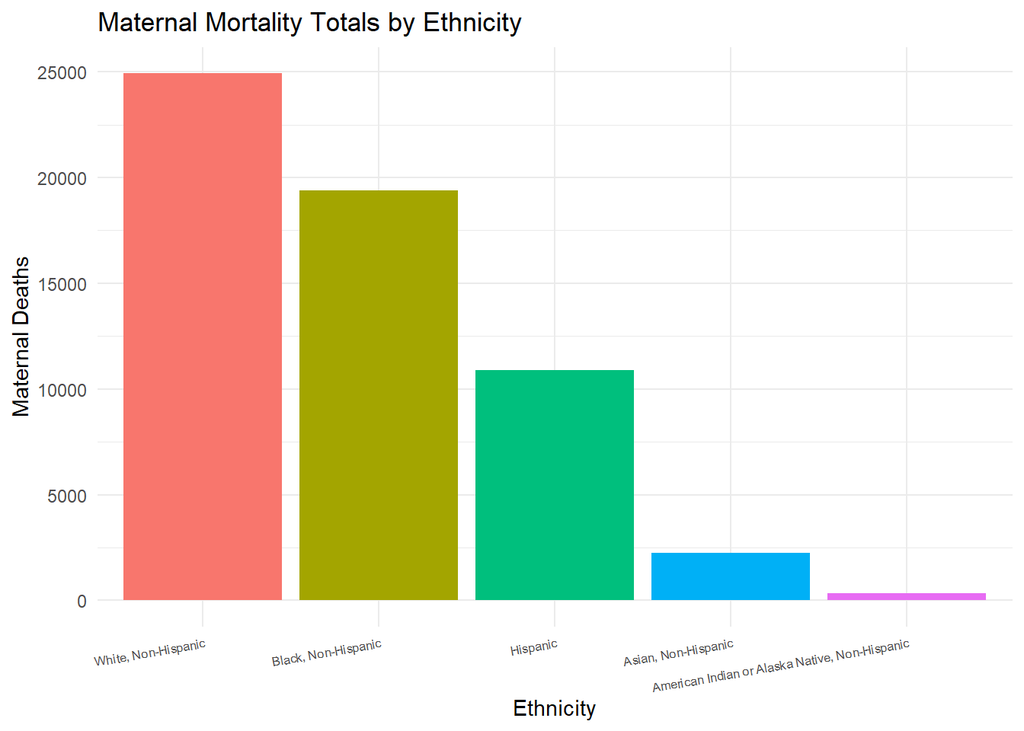

```r
#Data Exploration Graphs
colors=c('yellow','orange', 'blue', 'red', 'green')
df_ethnicity <- deaths_df %>%
    filter(!is.na(Ethnicity)) %>%
    group_by(Ethnicity) %>%
    summarise(Maternal_Deaths = sum(Maternal_Deaths, na.rm = TRUE))
desired_order <- c("White, Non-Hispanic", "Black, Non-Hispanic", "Hispanic", "Asian, Non-Hispanic", "American Indian or Alaska Native, Non-Hispanic")
df_ethnicity$Ethnicity <- factor(df_ethnicity$Ethnicity, levels = desired_order)
ggplot(df_ethnicity, aes(x = Ethnicity, y = Maternal_Deaths, fill = Ethnicity)) +
  geom_col() +
  labs(
    title = "Maternal Mortality Totals by Ethnicity",
    x = "Ethnicity",
    y = "Maternal Deaths"
  ) +
  theme_minimal() +
  theme(
    axis.text.x = element_text(angle = 10, hjust = 1, size = 6),  # angle and size
    legend.position = "none")
```

Below is a plot of monthly maternal deaths. The death count starts at 660 in January 2019, increases over time to a peak of 1249 in February 2022, decreases until November 2023 to 665, increases again slightly then holds close to 700 in the latter part of 2024.

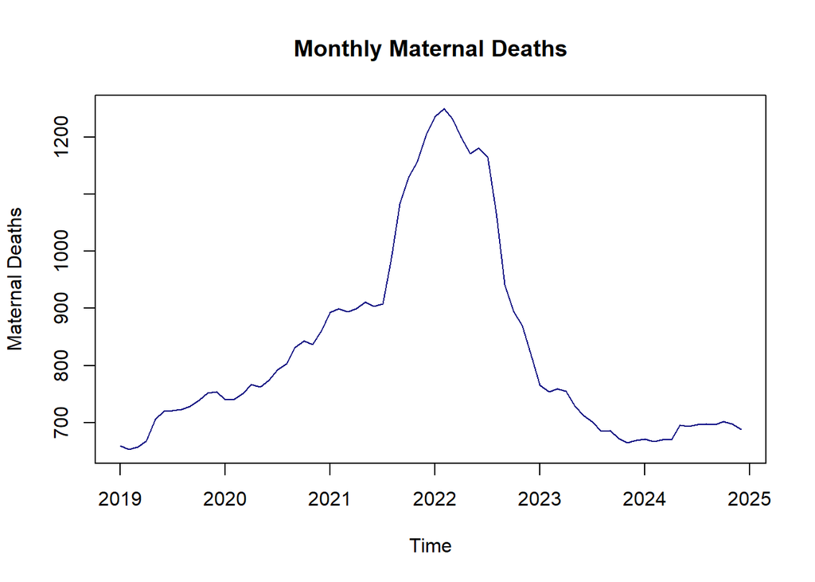

```r
total_df <- deaths_df%>%
  filter(Group=='Total')
total_ts <- ts(total_df$Maternal_Deaths,start=c(2019,1),frequency=12)
plot.ts(total_ts,main='Monthly Maternal Deaths',ylab='Maternal Deaths',xlab='Time',col='navy')
```

Similar to the above plot, this shows the monthly maternal death **rate**. The rate is considered the number of deaths per 100,000 live births. Since the number of live births is roughly constant, with only small fluctuations over the six year period, the monthly maternal death rate plot has the nearly identical shape as the monthly maternal death plot. The death rate goes from 17.4 in January 2019, to 33.8 in February 2022, to 18.4 in November 2023, then hovers around 19.3 in late 2024.

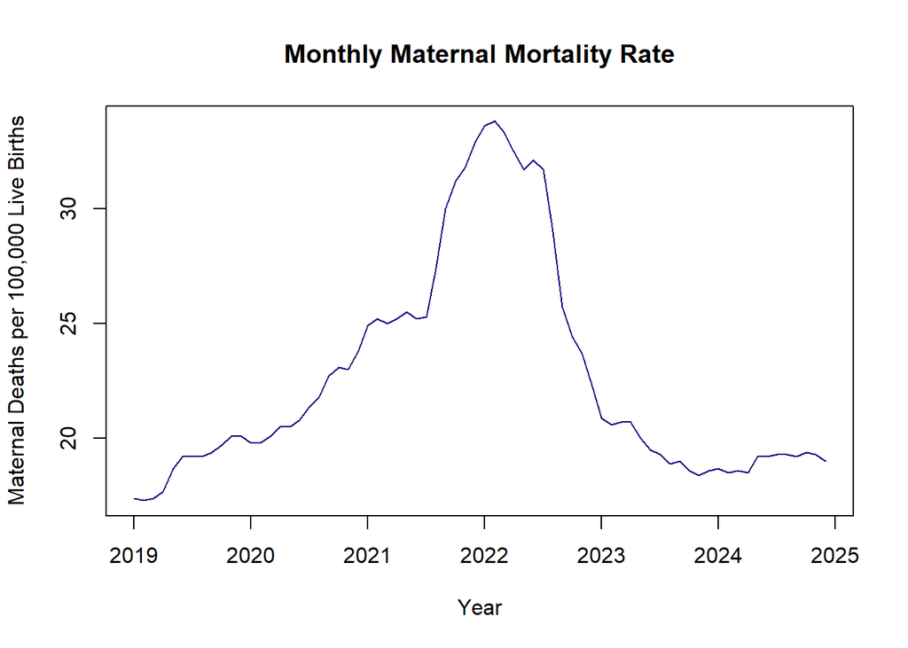

```r
df_tot_year_rate <- deaths_df%>%
  filter(Group=='Total')%>%
  select(Maternal_Mortality_Rate)
df_tot_year_rate_ts<-ts(df_tot_year_rate$Maternal_Mortality_Rate, start = c(2019,1), frequency = 12)
plot.ts(df_tot_year_rate_ts,main='Monthly Maternal Mortality Rate',xlab='Year',ylab='Maternal Deaths per 100,000 Live Births',col='navy')
```

Below are plots with maternal deaths and maternal mortality rate, both by ethnicity. In the left graph, note that white, black, and Hispanic deaths mirror the spike from the total monthly death plot, but Asian and American Indian or Alaska Native deaths stay steady. The right plot shows the highest death rates around 2022 for all ethnicities, including the two that did not experience an increase in deaths.

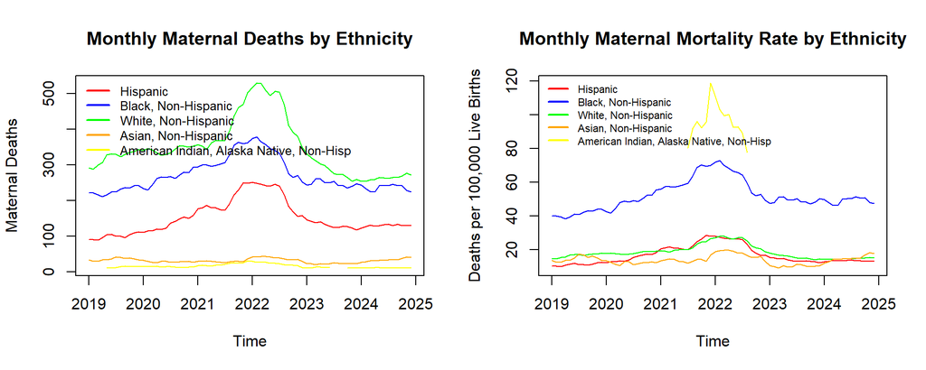

```r
par(mfrow = c(1, 2))
His <- filtered_df%>%
  filter(Subgroup=='Hispanic')%>%
  select(Maternal_Deaths)%>%
  rename(Hispanic=Maternal_Deaths)
bl <- filtered_df%>%
  filter(Subgroup=='Black, Non-Hispanic')%>%
  select(Maternal_Deaths)%>%
  rename('Black_Non-Hispanic' = Maternal_Deaths)
wh <- filtered_df%>%
  filter(Subgroup=='White, Non-Hispanic')%>%
  select(Maternal_Deaths)%>%
  rename('White_Non-Hispanic'=Maternal_Deaths)
as <- filtered_df%>%
  filter(Subgroup=='Asian, Non-Hispanic')%>%
  select(Maternal_Deaths)%>%
  rename('Asian_Non-Hispanic'=Maternal_Deaths)
aina <- df%>%
  filter(Subgroup=='American Indian or Alaska Native, Non-Hispanic')%>%
  select(Maternal_Deaths)%>%
  rename('American_Indian_or_Alaska_Native, Non-Hispanic'=Maternal_Deaths)
ethn_ts <- bind_cols(His,bl,wh,as,aina)
ethn_ts <- ts(ethn_ts, start=c(2019,1), frequency = 12)
colors=c('red','blue','green','orange','yellow')
plot.ts(ethn_ts, plot.type='single',main='Monthly Maternal Deaths by Ethnicity', ylab='Maternal Deaths',xlab='Time',col=colors)
legend("topleft",
       legend = c("Hispanic", "Black, Non-Hispanic", "White, Non-Hispanic",'Asian, Non-Hispanic','American Indian, Alaska Native, Non-Hisp'),  # Labels
       col = colors,
       lty = 1,
       lwd = 2,
       bty = "n",
       cex = 0.8)


HisR <- filtered_df%>%
  filter(Subgroup=='Hispanic')%>%
  select(Maternal_Mortality_Rate)%>%
  rename(Hispanic=Maternal_Mortality_Rate)
blR <- filtered_df%>%
  filter(Subgroup=='Black, Non-Hispanic')%>%
  select(Maternal_Mortality_Rate)%>%
  rename('Black_Non-Hispanic' = Maternal_Mortality_Rate)
whR <- filtered_df%>%
  filter(Subgroup=='White, Non-Hispanic')%>%
  select(Maternal_Mortality_Rate)%>%
  rename('White_Non-Hispanic'=Maternal_Mortality_Rate)
asR <- filtered_df%>%
  filter(Subgroup=='Asian, Non-Hispanic')%>%
  select(Maternal_Mortality_Rate)%>%
  rename('Asian_Non-Hispanic'=Maternal_Mortality_Rate)
ainaR <- df%>%
  filter(Subgroup=='American Indian or Alaska Native, Non-Hispanic')%>%
  select(Maternal_Mortality_Rate)%>%
  rename('American_Indian_or_Alaska_Native, Non-Hispanic'=Maternal_Mortality_Rate)
ethnR_ts <- bind_cols(HisR,blR,whR,asR,ainaR)
ethnR_ts <- ts(ethnR_ts, start=c(2019,1), frequency = 12)
colors=c('red','blue','green','orange','yellow')
plot.ts(ethnR_ts, plot.type='single',main='Monthly Maternal Mortality Rate by Ethnicity', ylab='Deaths per 100,000 Live Births',xlab='Time',col=colors)
legend("topleft",
       legend = c("Hispanic", "Black, Non-Hispanic", "White, Non-Hispanic",'Asian, Non-Hispanic','American Indian, Alaska Native, Non-Hisp'),  # Labels
       col = colors,
       lty = 1,
       lwd = 2,
       bty = "n",
       cex = 0.7)
```

```r
par(mfrow = c(1, 1))
```

Below are maternal deaths and death rate by age group. The greatest number of deaths occur in the 25-39 years group, reflective of the greater number of women of that age that give birth. Inc contrast, women 40 and over have the highest death rate, and women 25 and under have the smallest.

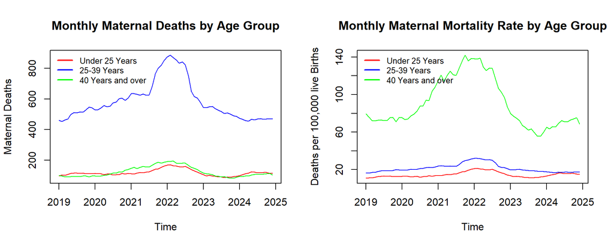

```r
par(mfrow = c(1, 2))
ageu25 <- deaths_df%>%
  filter(Subgroup=='Under 25 years')%>%
  select(Maternal_Deaths)%>%
  rename('Under_25_years'=Maternal_Deaths)
age25 <- filtered_df%>%
  filter(Subgroup=='25-39 years')%>%
  select(Maternal_Deaths)%>%
  rename('25-39_years' = Maternal_Deaths)
ageo40 <- filtered_df%>%
  filter(Subgroup=='40 years and over')%>%
  select(Maternal_Deaths)%>%
  rename('40_years_and_over'=Maternal_Deaths)
age_ts <- bind_cols(ageu25,age25,ageo40)
age_ts <- ts(age_ts, start=c(2019,1), frequency = 12)
colors=c('red','blue','green')
plot.ts(age_ts, plot.type='single',main='Monthly Maternal Deaths by Age Group', ylab='Maternal Deaths',xlab='Time',col=colors)
legend("topleft",
       legend = c("Under 25 Years", "25-39 Years", "40 Years and over"),  # Labels
       col = colors,
       lty = 1,
       lwd = 2,
       bty = "n",
       cex = 0.8)

ageu25R <- deaths_df%>%
  filter(Subgroup=='Under 25 years')%>%
  select(Maternal_Mortality_Rate)%>%
  rename('Under_25_years'=Maternal_Mortality_Rate)
age25R <- filtered_df%>%
  filter(Subgroup=='25-39 years')%>%
  select(Maternal_Mortality_Rate)%>%
  rename('25-39_years' = Maternal_Mortality_Rate)
ageo40R <- filtered_df%>%
  filter(Subgroup=='40 years and over')%>%
  select(Maternal_Mortality_Rate)%>%
  rename('40_years_and_over'=Maternal_Mortality_Rate)
ageR_ts <- bind_cols(ageu25R,age25R,ageo40R)
ageR_ts <- ts(ageR_ts, start=c(2019,1), frequency = 12)
colors=c('red','blue','green')
plot.ts(ageR_ts, plot.type='single',main='Monthly Maternal Mortality Rate by Age Group', ylab='Deaths per 100,000 live Births',xlab='Time',col=colors)
legend("topleft",
       legend = c("Under 25 Years", "25-39 Years", "40 Years and over"),  # Labels
       col = colors,
       lty = 1,
       lwd = 2,
       bty = "n",
       cex = 0.8)
```

```r
par(mfrow = c(1, 1))
```

Below are histograms showcasing the distribution of the outcome variable, Maternal Deaths. It roughly showcases a Negative Binomial Distribution.

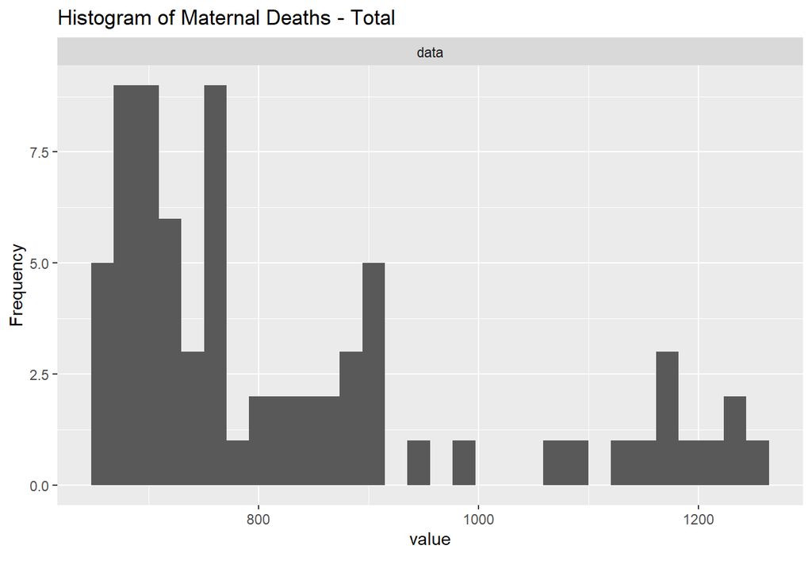

```r
#plot_histogram(deaths_df_ethnic$Maternal_Deaths,title='Histogram of Maternal Deaths - Ethnicity')
#plot_histogram(deaths_df_age$Maternal_Deaths, title='Histogram of Maternal Deaths - Age')
plot_histogram(total_df$Maternal_Deaths,title='Histogram of Maternal Deaths - Total')
```

These are boxplots of maternal deaths that show the distribution based on our created variable Dobbs Era (described later in Methods). Pre-Dobbs has a higher median as well as more variability in the death counts, than post-Dobbs. Both eras have outliers, but pre-Dobbs outliers are higher. Both eras are also right skewed.

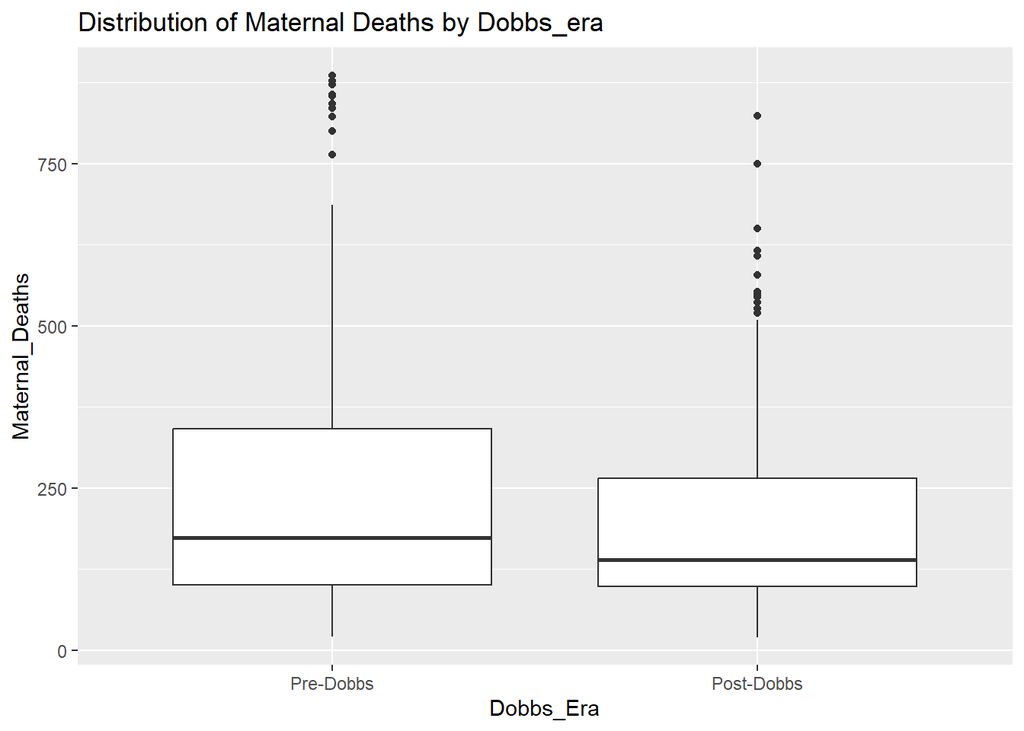

```r
#ggplot(deaths_df3, aes(x = Age_Group, y = Maternal_Deaths)) +
  #geom_boxplot() +
  #labs(title = "Distribution of Maternal Deaths by Age Group")

#ggplot(deaths_df3, aes(x = Ethnicity, y = Maternal_Deaths)) +
  #geom_boxplot() +
  #theme(axis.text.x = element_text(angle = 45, hjust = 1))+
 # labs(title = "Distribution of Maternal Deaths by Ethnicity")

ggplot(deaths_df3, aes(x = Dobbs_Era, y = Maternal_Deaths)) +
  geom_boxplot() +
  labs(title = "Distribution of Maternal Deaths by Dobbs_era")
```

### Modeling and Results

#### Data Preprocessing

Our data preprocessing began with renaming columns for clarity and filtering the dataset to ensure the modeling process was based on relevant and reliable observations. Specifically, we retained only observations where maternal deaths were greater than zero and where live births exceeded 100, in order to reduce noise and improve model fit. Observations with missing (NA) values were also removed.

Due to the structure of the dataset, the fixed-effect variables Ethnicity and Age Group had to be derived from the existing variables Group and Subgroup. The Group variable contained general categories, such as “Race and Hispanic origin” or “Age”, while the Subgroup variable provided the specific values associated with each group. For example:

- If Group was “Race and Hispanic origin”, then Subgroup could be “Hispanic”, “Black, not Hispanic”, or “White, not Hispanic”.
- If Group was “Age”, then Subgroup could be “25 and under”, “25–39”, or “40 and over”.

To create the Ethnicity variable, we extracted values from Subgroup when Group was “Race and Hispanic origin”. In cases where Group was not “Race and Hispanic origin”, the Ethnicity was set to “Unknown”. Similarly, the Age Group variable was constructed from Subgroup when Group was “Age”; otherwise, it was also labeled “Unknown”.

We converted the following variables to factor type: Year, Month, Ethnicity, and Age_Group. During model fitting, we encountered rank deficiency issues due to the “Unknown” level in Age_Group (which made estimates for that level non-estimable). However, for the sake of preserving the full structure and interpretability of the model, we retained the “Unknown” category rather than removing it.

To facilitate modeling, we created two intermediate data frames:

- One retained only ethnicity-related observations.
- The other retained only age group-related observations.

After cleaning and filtering each subset, we merged them to create a unified dataset. We explicitly defined factor levels for both Ethnicity and Age_Group, including an “Unknown” level in each. This ensured that model execution would not fail when including both variables as fixed effects.

Lastly, we created a new variable, Dobbs_Era, to distinguish between periods before and after the U.S. Supreme Court’s overturning of Roe v. Wade on June 24, 2022. To do this, we first constructed a Date variable by combining Year, Month, and the first day of each month. We then used a cutoff date (2022-06-24) to classify each observation as “Pre-Dobbs” or “Post-Dobbs”. This new factor variable was included as a fixed effect in the models to investigate whether the Dobbs decision had a measurable impact on maternal deaths.

#### Modeling

We created models with different combinations of fixed effects, including Ethnicity, Age Group, and Dobbs Era, along with Year as a random effect. Initially, we tested a Poisson model, which showed significant evidence of overdispersion. Due to this, we proceeded with the Negative Binomial Distribution as the family for our models.

During model fitting, we encountered issues with rank deficiency caused by the parameter Age_GroupUnknown, which was not estimable due to insufficient or non-informative data in that category.

Below is the output of the Poisson model that we ran, and then the overdispersion test.

```r
poissonmodel_glmm_all <- glmer(Maternal_Deaths ~ Ethnicity +Age_Group+ Dobbs_Era+(1|Year),
                              offset=log(Live_Births),
                              family = poisson(link = "log"),
                              data = deaths_df3)

poissonmodel_glmm_all
```

```
Generalized linear mixed model fit by maximum likelihood (Laplace
  Approximation) [glmerMod]
 Family: poisson  ( log )
Formula: Maternal_Deaths ~ Ethnicity + Age_Group + Dobbs_Era + (1 | Year)
   Data: deaths_df3
 Offset: log(Live_Births)
      AIC       BIC    logLik -2*log(L)  df.resid
 4878.734  4921.234 -2429.367  4858.734       508
Random effects:
 Groups Name        Std.Dev.
 Year   (Intercept) 0.1745
Number of obs: 518, groups:  Year, 6
Fixed Effects:
                                            (Intercept)
                                               -8.79720
                           EthnicityBlack, Non-Hispanic
                                                1.31118
                           EthnicityWhite, Non-Hispanic
                                                0.28576
                                      EthnicityHispanic
                                                0.17350
EthnicityAmerican Indian or Alaska Native, Non-Hispanic
                                                1.65719
                                       EthnicityUnknown
                                                0.04122
                                   Age_Group25-39 years
                                                0.39262
                             Age_Group40 years and over
                                                1.81968
                                    Dobbs_EraPost-Dobbs
                                               -0.22567
fit warnings:
fixed-effect model matrix is rank deficient so dropping 1 column / coefficient
```

```r
check_overdispersion(poissonmodel_glmm_all)
```

```
# Overdispersion test

       dispersion ratio =    2.490
  Pearson's Chi-Squared = 1265.114
                p-value =  < 0.001
```

Below we run four Negative Binomial GLMM models. The output is displayed, and then a table summarizing the results follows.

```r
##with offset # all fixed effects
all_glmmodel_nb <- glmmTMB(
  Maternal_Deaths ~  Ethnicity + Age_Group +Dobbs_Era+ (1|Year),
  offset=log(Live_Births),
  family = nbinom2,
  data = deaths_df3
)
summary(all_glmmodel_nb)
```

```
 Family: nbinom2  ( log )
Formula:
Maternal_Deaths ~ Ethnicity + Age_Group + Dobbs_Era + (1 | Year)
Data: deaths_df3
 Offset: log(Live_Births)

      AIC       BIC    logLik -2*log(L)  df.resid
   4567.5    4614.2   -2272.7    4545.5       507

Random effects:

Conditional model:
 Groups Name        Variance Std.Dev.
 Year   (Intercept) 0.03158  0.1777
Number of obs: 518, groups:  Year, 6

Dispersion parameter for nbinom2 family ():  148

Conditional model:
                                                        Estimate Std. Error
(Intercept)                                             -8.79687    0.07678
EthnicityBlack, Non-Hispanic                             1.31563    0.02627
EthnicityWhite, Non-Hispanic                             0.28329    0.02604
EthnicityHispanic                                        0.16204    0.02704
EthnicityAmerican Indian or Alaska Native, Non-Hispanic  1.65241    0.06285
EthnicityUnknown                                         0.04364    0.02750
Age_Group25-39 years                                     0.38817    0.01821
Age_Group40 years and over                               1.81031    0.02053
Age_GroupUnknown                                              NA         NA
Dobbs_EraPost-Dobbs                                     -0.22081    0.02303
                                                        z value Pr(>|z|)
(Intercept)                                             -114.57  < 2e-16 ***
EthnicityBlack, Non-Hispanic                              50.08  < 2e-16 ***
EthnicityWhite, Non-Hispanic                              10.88  < 2e-16 ***
EthnicityHispanic                                          5.99 2.06e-09 ***
EthnicityAmerican Indian or Alaska Native, Non-Hispanic   26.29  < 2e-16 ***
EthnicityUnknown                                           1.59    0.113
Age_Group25-39 years                                      21.31  < 2e-16 ***
Age_Group40 years and over                                88.17  < 2e-16 ***
Age_GroupUnknown                                             NA       NA
Dobbs_EraPost-Dobbs                                       -9.59  < 2e-16 ***
---
Signif. codes:  0 '***' 0.001 '**' 0.01 '*' 0.05 '.' 0.1 ' ' 1
```

```r
ethnicity_agegroup_glmmodel_nb <- glmmTMB(
  Maternal_Deaths ~  Ethnicity+ Age_Group + (1|Year),
  offset=log(Live_Births),
  family = nbinom2,
  data = deaths_df3
)
summary(ethnicity_agegroup_glmmodel_nb)
```

```
 Family: nbinom2  ( log )
Formula:          Maternal_Deaths ~ Ethnicity + Age_Group + (1 | Year)
Data: deaths_df3
 Offset: log(Live_Births)

      AIC       BIC    logLik -2*log(L)  df.resid
   4647.6    4690.1   -2313.8    4627.6       508

Random effects:

Conditional model:
 Groups Name        Variance Std.Dev.
 Year   (Intercept) 0.0326   0.1805
Number of obs: 518, groups:  Year, 6

Dispersion parameter for nbinom2 family ():  107

Conditional model:
                                                        Estimate Std. Error
(Intercept)                                             -8.88725    0.07754
EthnicityBlack, Non-Hispanic                             1.31581    0.02763
EthnicityWhite, Non-Hispanic                             0.28254    0.02742
EthnicityHispanic                                        0.16063    0.02836
EthnicityAmerican Indian or Alaska Native, Non-Hispanic  1.68338    0.06458
EthnicityUnknown                                         0.04366    0.02881
Age_Group25-39 years                                     0.38788    0.02012
Age_Group40 years and over                               1.80898    0.02225
Age_GroupUnknown                                              NA         NA
                                                        z value Pr(>|z|)
(Intercept)                                             -114.61  < 2e-16 ***
EthnicityBlack, Non-Hispanic                              47.62  < 2e-16 ***
EthnicityWhite, Non-Hispanic                              10.31  < 2e-16 ***
EthnicityHispanic                                          5.66 1.49e-08 ***
EthnicityAmerican Indian or Alaska Native, Non-Hispanic   26.07  < 2e-16 ***
EthnicityUnknown                                           1.52     0.13
Age_Group25-39 years                                      19.28  < 2e-16 ***
Age_Group40 years and over                                81.32  < 2e-16 ***
Age_GroupUnknown                                             NA       NA
---
Signif. codes:  0 '***' 0.001 '**' 0.01 '*' 0.05 '.' 0.1 ' ' 1
```

```r
##with no offset # all fixed effects #with not offset we can just use maternal mortality rate per 100,0000 live_births
allno_glmmodel_nb <- glmmTMB(
  Maternal_Deaths ~  Ethnicity + Age_Group+ Dobbs_Era + (1 |Year),
  family = nbinom2,
  data = deaths_df3
)
summary(allno_glmmodel_nb)
```

```
 Family: nbinom2  ( log )
Formula:
Maternal_Deaths ~ Ethnicity + Age_Group + Dobbs_Era + (1 | Year)
Data: deaths_df3

      AIC       BIC    logLik -2*log(L)  df.resid
   4560.6    4607.3   -2269.3    4538.6       507

Random effects:

Conditional model:
 Groups Name        Variance Std.Dev.
 Year   (Intercept) 0.02885  0.1698
Number of obs: 518, groups:  Year, 6

Dispersion parameter for nbinom2 family ():  155

Conditional model:
                                                        Estimate Std. Error
(Intercept)                                              3.51596    0.07371
EthnicityBlack, Non-Hispanic                             2.16044    0.02612
EthnicityWhite, Non-Hispanic                             2.40591    0.02589
EthnicityHispanic                                        1.56973    0.02690
EthnicityAmerican Indian or Alaska Native, Non-Hispanic -0.48610    0.06264
EthnicityUnknown                                         1.33561    0.02736
Age_Group25-39 years                                     1.59868    0.01798
Age_Group40 years and over                               0.03846    0.02033
Age_GroupUnknown                                              NA         NA
Dobbs_EraPost-Dobbs                                     -0.22215    0.02267
                                                        z value Pr(>|z|)
(Intercept)                                               47.70  < 2e-16 ***
EthnicityBlack, Non-Hispanic                              82.72  < 2e-16 ***
EthnicityWhite, Non-Hispanic                              92.91  < 2e-16 ***
EthnicityHispanic                                         58.36  < 2e-16 ***
EthnicityAmerican Indian or Alaska Native, Non-Hispanic   -7.76  8.5e-15 ***
EthnicityUnknown                                          48.82  < 2e-16 ***
Age_Group25-39 years                                      88.90  < 2e-16 ***
Age_Group40 years and over                                 1.89   0.0585 .
Age_GroupUnknown                                             NA       NA
Dobbs_EraPost-Dobbs                                       -9.80  < 2e-16 ***
---
Signif. codes:  0 '***' 0.001 '**' 0.01 '*' 0.05 '.' 0.1 ' ' 1
```

```r
ethnicity_agegroupno_glmmodel_nb <- glmmTMB(
  Maternal_Deaths ~  Ethnicity+ Age_Group + (1 |Year),
  family = nbinom2,
  data = deaths_df3
)
summary(ethnicity_agegroupno_glmmodel_nb)
```

```
 Family: nbinom2  ( log )
Formula:          Maternal_Deaths ~ Ethnicity + Age_Group + (1 | Year)
Data: deaths_df3

      AIC       BIC    logLik -2*log(L)  df.resid
   4643.6    4686.1   -2311.8    4623.6       508

Random effects:

Conditional model:
 Groups Name        Variance Std.Dev.
 Year   (Intercept) 0.03063  0.175
Number of obs: 518, groups:  Year, 6

Dispersion parameter for nbinom2 family ():  109

Conditional model:
                                                        Estimate Std. Error
(Intercept)                                              3.42547    0.07539
EthnicityBlack, Non-Hispanic                             2.16003    0.02752
EthnicityWhite, Non-Hispanic                             2.40480    0.02731
EthnicityHispanic                                        1.56795    0.02826
EthnicityAmerican Indian or Alaska Native, Non-Hispanic -0.45485    0.06442
EthnicityUnknown                                         1.33507    0.02870
Age_Group25-39 years                                     1.59851    0.01995
Age_Group40 years and over                               0.03698    0.02209
Age_GroupUnknown                                              NA         NA
                                                        z value Pr(>|z|)
(Intercept)                                               45.44  < 2e-16 ***
EthnicityBlack, Non-Hispanic                              78.49  < 2e-16 ***
EthnicityWhite, Non-Hispanic                              88.07  < 2e-16 ***
EthnicityHispanic                                         55.49  < 2e-16 ***
EthnicityAmerican Indian or Alaska Native, Non-Hispanic   -7.06 1.65e-12 ***
EthnicityUnknown                                          46.51  < 2e-16 ***
Age_Group25-39 years                                      80.12  < 2e-16 ***
Age_Group40 years and over                                 1.67   0.0942 .
Age_GroupUnknown                                             NA       NA
---
Signif. codes:  0 '***' 0.001 '**' 0.01 '*' 0.05 '.' 0.1 ' ' 1
```

Here is the table summarizing model performance parameters.

```r
MuMIn::model.sel(all_glmmodel_nb,allno_glmmodel_nb, ethnicity_agegroup_glmmodel_nb, ethnicity_agegroupno_glmmodel_nb)
```

```
Model selection table
                                 cnd((Int)) dsp((Int)) cnd(Age_Grp)
allno_glmmodel_nb                     3.516          +            +
all_glmmodel_nb                      -8.797          +            +
ethnicity_agegroupno_glmmodel_nb      3.425          +            +
ethnicity_agegroup_glmmodel_nb       -8.887          +            +
                                 cnd(Dbb_Era) cnd(Eth) cnd(off(log(Liv_Brt)))
allno_glmmodel_nb                           +        +
all_glmmodel_nb                             +        +                      +
ethnicity_agegroupno_glmmodel_nb                     +
ethnicity_agegroup_glmmodel_nb                       +                      +
                                 offset df    logLik   AICc delta weight
allno_glmmodel_nb                       11 -2269.287 4561.1  0.00  0.969
all_glmmodel_nb                  l(L_B) 11 -2272.739 4568.0  6.90  0.031
ethnicity_agegroupno_glmmodel_nb        10 -2311.825 4644.1 82.99  0.000
ethnicity_agegroup_glmmodel_nb   l(L_B) 10 -2313.794 4648.0 86.93  0.000
Abbreviations:
 offset: l(L_B) = 'log(Live_Births)'
Models ranked by AICc(x)
Random terms (all models):
  cond(1 | Year)
```

We ran models with and without the offset term log(Live_Births) to evaluate differences in model fit, particularly using Akaike Information Criterion (AIC) as the primary metric for comparison. A lower AIC indicates a better-fitting model.

The best-performing models included the fixed effects Ethnicity, Age_Group, and Dobbs_Era, with Year as a random effect. The second place would be models with fixed effects Ethnicity and Age group and random effect Year. All models dropped the Age Group Unknown factor from inclusion.

The model with the lowest AIC (4561.1) included all fixed effects but excluded the offset. The next-best model, with an AIC of 4568.0, included the same fixed effects with the offset. Despite the slightly higher AIC, the offset-included model is more appropriate and valid, as it accounts for differences in exposure across groups (i.e., varying numbers of live births).

Excluding the offset implies that all observations have equal exposure — suggesting, for instance, that every ethnic group has the same number of live births each year, which is not the case. In contrast, including the offset adjusts for the actual number of live births, yielding rate-based estimates that correctly reflect the underlying population structure. While the offset-free model appears better based on AIC alone, it leads to biased estimates due to ignoring exposure variability (Hilbe 2011), (Nguyen 2020), (Ha 2023).

The majority of our visualizations will be based on the model with all fixed effects and with offset. Visualizations based on the non-offset model are included later for comparison with the offset model.

Here is the equation for a our chosen model in regression equation format:
$$\begin{align*}
\log(\mathbb{E}[\text{Maternal Deaths}_i]) &= \beta_0
+ \beta_1 \cdot \text{Black}_i
+ \beta_2 \cdot \text{White}_i
+ \beta_3 \cdot \text{Hispanic}_i \\
&+ \beta_4 \cdot \text{American Indian or Alaska Native}_i
+ \beta_5 \cdot \text{EthnicityUnknown}_i \\
&+ \beta_6 \cdot \text{Age 25-39}_i
+ \beta_7 \cdot \text{Age 40 Plus}_i
+ \beta_8 \cdot \text{Post Dobbs}_i
+ b_{\text{Year}[i]} \\
&+ \log(\text{Live Births}_i)
\end{align*}$$

Here is the equation for the non-offset model:

$$\begin{align*}
\log(\mathbb{E}[\text{Maternal Deaths}_i]) &= \beta_0
+ \beta_1 \cdot \text{Black}_i
+ \beta_2 \cdot \text{White}_i
+ \beta_3 \cdot \text{Hispanic}_i \\
&+ \beta_4 \cdot \text{American Indian or Alaska Native}_i
+ \beta_5 \cdot \text{EthnicityUnknown}_i \\
&+ \beta_6 \cdot \text{Age 25-39}_i
+ \beta_7 \cdot \text{Age 40 Plus}_i
+ \beta_8 \cdot \text{Post Dobbs}_i
+ b_{\text{Year}[i]}
\end{align*}$$

Here are the beta estimates in a equation model format for the offset model:

#### Verifying Assumptions

Our chosen model adheres to all the model assumptions for a Negative Binomial GLMM.

- The response variable and the predictors have a linear relationship within the levels of random effects

The graph shows the residual values of the model and the fitted values of the model and the scatter points are the fitted values of the model. The red reference line is where the residuals equal zero.There are no patterns with the scatter points which provides evidence that the response variable and the predictors have linear relationship within the levels of random effect (year). Additionally, The blue LOESS smoother line is close to the red reference line of zero, which provides further evidence of the linear relationship. The residuals are roughly centered around zero across the range of values. The variability of the residuals on the left of the graph suggests heteroscedasticity, which is expected.

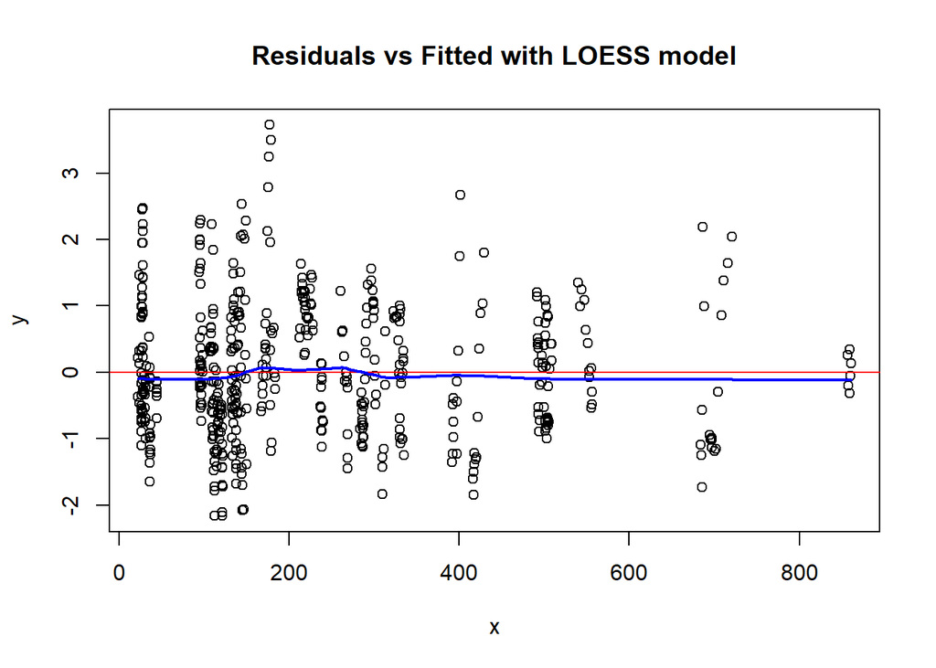

```r
resid_vals<-resid(all_glmmodel_nb,type = "pearson")
fitted_vals <- predict(all_glmmodel_nb,type = "response")

x <- jitter(fitted_vals)
y<-resid_vals

plot(x, y, main = "Residuals vs Fitted with LOESS model")
abline(h = 0, col = "red")
lines(lowess(x, y), col = "blue", lwd = 2)
```

- The response variable is assumed to follow a negative binomial distribution, with $\sigma^2>\mu$.

```r
#check overdispersion
total_df %>% summarize(mean(Maternal_Deaths),
var(Maternal_Deaths))
```

```
  mean(Maternal_Deaths) var(Maternal_Deaths)
1              828.8889             30819.62
```

- The Independence of residual and Random Effects assumption is met
- The graph below plots the points of the the random effect (year) residuals falls on the red reference line of random intercept quantiles estimates versus normal distribution quantiles and the red reference line represent where random effect residual points would lie if random intercepts were normally distributed.
- The Q-Q plot of the random intercepts for Year suggests the distribution of the random effects is approximately normal. There is slight deviations at the extremes due to the low number of years.

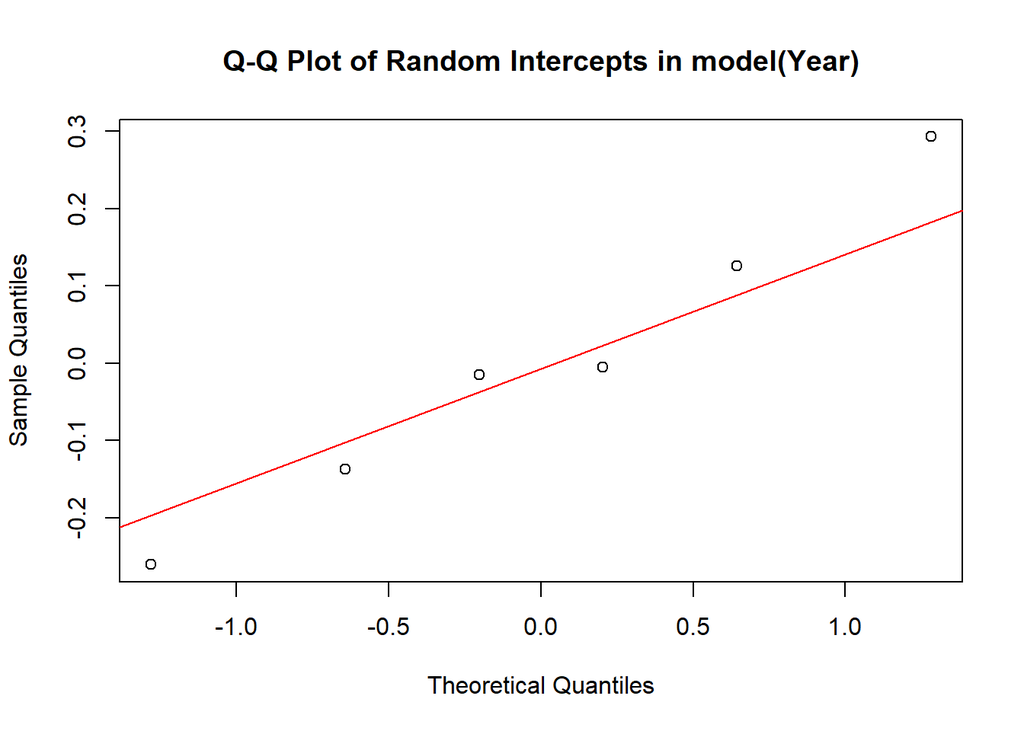

```r
re_year <- ranef(all_glmmodel_nb)$cond$Year[[1]]

qqnorm(re_year, main = "Q-Q Plot of Random Intercepts in model(Year)")
qqline(re_year, col = "red")
```

- The random effects are assumed to be normally distributed, with mean 0 and variance $\sigma$.
- The graph plots a blue density curve of random effect distribution. The red dashed line of the distribution indicates the distribution of ideal normal distribution with same means and standard deviation. The blue density curve falls approximately within the red line so the random effects are approximately normal. The approximately normal blue density of the random effect(year) could be expected to have mild deviations since we are working with count data. Yet, since most of the blue density falls within the ideal normal distribution curve then there is normality of random effects

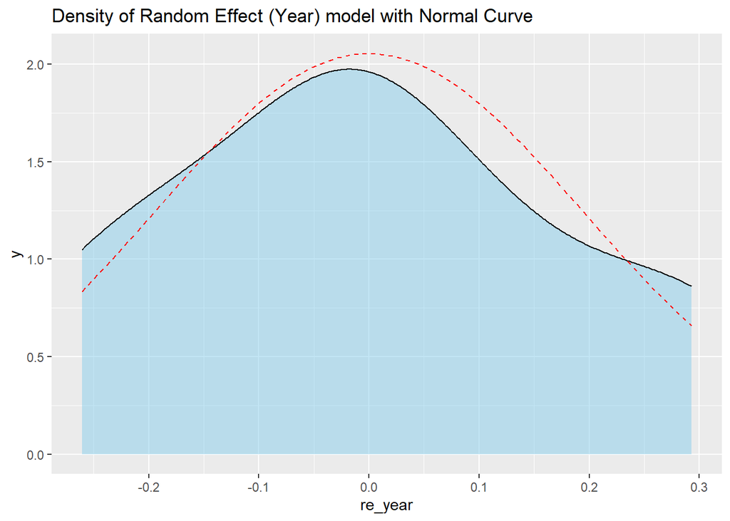

```r
#Normality of Random effects



re_year <- ranef(all_glmmodel_nb)$cond$Year[["(Intercept)"]] #extract year random effect intercepts as numeric

df_re <- data.frame(re = re_year)

ggplot(df_re, aes(x = re_year)) +
  geom_density(fill = "skyblue", alpha = 0.5) +#density curve of random effect distribution
  stat_function(fun = dnorm, args = list(mean = mean(re_year), sd = sd(re_year)),
                color = "red", linetype = "dashed") +##red is ideal normal distribution with same means and standard deviation
  ggtitle("Density of Random Effect (Year) model with Normal Curve")
```

#### Results

This is the offset model summary output:

```r
sjPlot::tab_model(all_glmmodel_nb,
          transform = NULL,
          show.se = TRUE,         # show standard error
          show.stat = TRUE,       # show z-values
          show.p = TRUE,
          title = "GLMM negative binomial model with offset (Log Estimates)")
```

GLMM negative binomial model with offset (Log Estimates)

|  | Maternal_Deaths |  |  |  |  |
| --- | --- | --- | --- | --- | --- |
| Predictors | Log-Mean | std. Error | CI | Statistic | p |
| (Intercept) | -8.80 | 0.08 | -8.95 – -8.65 | -114.57 | **<0.001** |
| Ethnicity [Black, Non-Hispanic] | 1.32 | 0.03 | 1.26 – 1.37 | 50.08 | **<0.001** |
| Ethnicity [White, Non-Hispanic] | 0.28 | 0.03 | 0.23 – 0.33 | 10.88 | **<0.001** |
| Ethnicity [Hispanic] | 0.16 | 0.03 | 0.11 – 0.22 | 5.99 | **<0.001** |
| Ethnicity [American Indian or Alaska Native, Non-Hispanic] | 1.65 | 0.06 | 1.53 – 1.78 | 26.29 | **<0.001** |
| Ethnicity [Unknown] | 0.04 | 0.03 | -0.01 – 0.10 | 1.59 | 0.113 |
| Age_Group25-39 years | 0.39 | 0.02 | 0.35 – 0.42 | 21.31 | **<0.001** |
| Age Group [40 years and over] | 1.81 | 0.02 | 1.77 – 1.85 | 88.17 | **<0.001** |
| Dobbs Era [Post-Dobbs] | -0.22 | 0.02 | -0.27 – -0.18 | -9.59 | **<0.001** |
| Random Effects |  |  |  |  |  |
| σ<sup>2</sup> | 8.00 |  |  |  |  |
| τ<sub>00</sub> <sub>Year</sub> | 0.03 |  |  |  |  |
| ICC | 0.00 |  |  |  |  |
| N <sub>Year</sub> | 6 |  |  |  |  |
| Observations | 518 |  |  |  |  |
| Marginal R<sup>2</sup> / Conditional R<sup>2</sup> | 0.056 / 0.059 |  |  |  |  |

This is a model summary output with beta coefficients exponentiation into incidence rate ratios.

```r
library(sjPlot)
tab_model(all_glmmodel_nb,
          title = " GLMM negative binomial model with offset")
```

GLMM negative binomial model with offset

|  | Maternal_Deaths |  |  |
| --- | --- | --- | --- |
| Predictors | Incidence Rate Ratios | CI | p |
| (Intercept) | 0.00 | 0.00 – 0.00 | **<0.001** |
| Ethnicity [Black, Non-Hispanic] | 3.73 | 3.54 – 3.92 | **<0.001** |
| Ethnicity [White, Non-Hispanic] | 1.33 | 1.26 – 1.40 | **<0.001** |
| Ethnicity [Hispanic] | 1.18 | 1.12 – 1.24 | **<0.001** |
| Ethnicity [American Indian or Alaska Native, Non-Hispanic] | 5.22 | 4.61 – 5.90 | **<0.001** |
| Ethnicity [Unknown] | 1.04 | 0.99 – 1.10 | 0.113 |
| Age_Group25-39 years | 1.47 | 1.42 – 1.53 | **<0.001** |
| Age Group [40 years and over] | 6.11 | 5.87 – 6.36 | **<0.001** |
| Dobbs Era [Post-Dobbs] | 0.80 | 0.77 – 0.84 | **<0.001** |
| Random Effects |  |  |  |
| σ<sup>2</sup> | 8.00 |  |  |
| τ<sub>00</sub> <sub>Year</sub> | 0.03 |  |  |
| ICC | 0.00 |  |  |
| N <sub>Year</sub> | 6 |  |  |
| Observations | 518 |  |  |
| Marginal R<sup>2</sup> / Conditional R<sup>2</sup> | 0.056 / 0.059 |  |  |

##### Results Snapshot by Predictor (Offset Model)

Dobbs:

- There was a 20% lower rate in maternal mortality after Dobbs was passed compared to prior the passing of Dobbs

##### Model Fit

The residual variance of the model is 7.99, representing the variability in maternal deaths not explained by either fixed or random effects. The marginal R², which reflects the proportion of variance explained by fixed effects alone, is 5.6%. This indicates that the fixed effects account for only a small portion of the variability in maternal deaths. The conditional R², which includes both fixed and random effects, is 5.9%. This slight increase suggests that the random effect of Year contributes minimally to improving the model’s explanatory power. The low proportion of variance explained by the model may be due to the absence of additional random effects—such as State—or missing fixed effects that capture important factors like socioeconomic status, healthcare access, or prenatal care quality. Despite the low R² values, the statistical significance of the fixed effects remains meaningful, as it underscores the presence of significant associations between the explanatory variables and maternal mortality. Since our focus is not on prediction, but rather on understanding these relationships, a higher R² is not essential for the model to be informative.

Below is a brief glimpse at the non-offset GLMM model table estimates.

```r
sjPlot::tab_model(allno_glmmodel_nb,
          transform = NULL, #original log and not exponiated
          show.se = TRUE,         # show standard error
          show.stat = TRUE,       # show z-values
          show.p = TRUE,
          title = "Fixed Effects of GLMM model without offset (Log Estimates)")
```

Fixed Effects of GLMM model without offset (Log Estimates)

|  | Maternal_Deaths |  |  |  |  |
| --- | --- | --- | --- | --- | --- |
| Predictors | Log-Mean | std. Error | CI | Statistic | p |
| (Intercept) | 3.52 | 0.07 | 3.37 – 3.66 | 47.70 | **<0.001** |
| Ethnicity [Black, Non-Hispanic] | 2.16 | 0.03 | 2.11 – 2.21 | 82.72 | **<0.001** |
| Ethnicity [White, Non-Hispanic] | 2.41 | 0.03 | 2.36 – 2.46 | 92.91 | **<0.001** |
| Ethnicity [Hispanic] | 1.57 | 0.03 | 1.52 – 1.62 | 58.36 | **<0.001** |
| Ethnicity [American Indian or Alaska Native, Non-Hispanic] | -0.49 | 0.06 | -0.61 – -0.36 | -7.76 | **<0.001** |
| Ethnicity [Unknown] | 1.34 | 0.03 | 1.28 – 1.39 | 48.82 | **<0.001** |
| Age_Group25-39 years | 1.60 | 0.02 | 1.56 – 1.63 | 88.90 | **<0.001** |
| Age Group [40 years and over] | 0.04 | 0.02 | -0.00 – 0.08 | 1.89 | 0.058 |
| Dobbs Era [Post-Dobbs] | -0.22 | 0.02 | -0.27 – -0.18 | -9.80 | **<0.001** |
| Random Effects |  |  |  |  |  |
| σ<sup>2</sup> | 0.01 |  |  |  |  |
| τ<sub>00</sub> <sub>Year</sub> | 0.03 |  |  |  |  |
| ICC | 0.73 |  |  |  |  |
| N <sub>Year</sub> | 6 |  |  |  |  |
| Observations | 518 |  |  |  |  |
| Marginal R<sup>2</sup> / Conditional R<sup>2</sup> | 0.957 / 0.988 |  |  |  |  |

```r
sjPlot::tab_model(allno_glmmodel_nb,
          title = "Fixed Effects from GLMM with outset(Incidence Rates Ratios)")
```

Fixed Effects from GLMM with outset(Incidence Rates Ratios)

|  | Maternal_Deaths |  |  |
| --- | --- | --- | --- |
| Predictors | Incidence Rate Ratios | CI | p |
| (Intercept) | 33.65 | 29.12 – 38.88 | **<0.001** |
| Ethnicity [Black, Non-Hispanic] | 8.67 | 8.24 – 9.13 | **<0.001** |
| Ethnicity [White, Non-Hispanic] | 11.09 | 10.54 – 11.67 | **<0.001** |
| Ethnicity [Hispanic] | 4.81 | 4.56 – 5.07 | **<0.001** |
| Ethnicity [American Indian or Alaska Native, Non-Hispanic] | 0.62 | 0.54 – 0.70 | **<0.001** |
| Ethnicity [Unknown] | 3.80 | 3.60 – 4.01 | **<0.001** |
| Age_Group25-39 years | 4.95 | 4.78 – 5.12 | **<0.001** |
| Age Group [40 years and over] | 1.04 | 1.00 – 1.08 | 0.058 |
| Dobbs Era [Post-Dobbs] | 0.80 | 0.77 – 0.84 | **<0.001** |
| Random Effects |  |  |  |
| σ<sup>2</sup> | 0.01 |  |  |
| τ<sub>00</sub> <sub>Year</sub> | 0.03 |  |  |
| ICC | 0.73 |  |  |
| N <sub>Year</sub> | 6 |  |  |
| Observations | 518 |  |  |
| Marginal R<sup>2</sup> / Conditional R<sup>2</sup> | 0.957 / 0.988 |  |  |

Even more problematic is the model’s marginal R² of 95.7%, indicating that fixed effects alone explain nearly all of the variance in maternal mortality. The conditional R² rises to 98.8% when including random effects. These values are unrealistically high, and provide further evidence of unaccounted exposure in a model without offset.

- There is no singularity of the random effect (year)which demonstrates that the random effect year does contribute to the model.
- The collinearity VIF numbers have low values which suggests that none of the predictor variables are highly correlated which each other

```r
check_singularity(all_glmmodel_nb)
```

```
[1] FALSE
```

```r
check_collinearity(all_glmmodel_nb)
```

```
# Check for Multicollinearity

Low Correlation

      Term  VIF       VIF 95% CI adj. VIF Tolerance Tolerance 95% CI
 Ethnicity 2.56 [2.25,     2.95]     1.60      0.39     [0.34, 0.44]
 Age_Group 2.55 [2.24,     2.93]     1.60      0.39     [0.34, 0.45]
 Dobbs_Era 1.00 [1.00, 1.07e+07]     1.00      1.00     [0.00, 1.00]
```

This tests if the model is overdispersed since the ratio given is around 1 and provides evidence that there is no overdispersion and neither is the p value which is much greater that (p <0.05) which also indicates there is no significant overdispersion with this model.

```r
overdisp_fun <- function(all_glmmodel_nb) {
  rdf <- df.residual(all_glmmodel_nb)
  rp <- residuals(all_glmmodel_nb, type = "pearson")
  Pearson.chisq <- sum(rp^2)
  prat <- Pearson.chisq / rdf
  pval <- pchisq(Pearson.chisq, df = rdf, lower.tail = FALSE)
  c(chisq = Pearson.chisq, ratio = prat, rdf = rdf, p = pval)
}

overdisp_fun(all_glmmodel_nb)
```

```
      chisq       ratio         rdf           p
524.0059148   1.0335422 507.0000000   0.2914781
```

```r
#ratio is around 1 which is good and not too indicative of overdispersion
#pp-value is greater that P<0.005 so that means there is no significant overdispersion
```

```r
install.packages("ggeffects")  # if not yet installed
```

These are predictions of maternal deaths by individual fixed effect (Ethnicity, Age Group) for with and without offset models. As you can see, there are vast differences between the plots with and without offset. Visually one can see without offset that the most maternal death counts are white women (who make up the majority of the population) followed by black women. However, with offset the exposure is clear and there can be brought evidence of the unfortunate inflated maternal mortality rates of American Indian or Alaska Native women and black women.

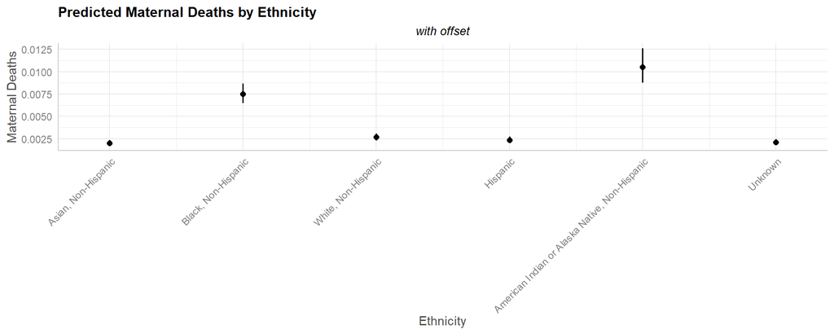

```r
par(mfrow = c(1, 2))

library(ggeffects)
library(patchwork)

#  predictions by ethnicity
pred_eth1 <- ggpredict(all_glmmodel_nb, terms = "Ethnicity")
plot(pred_eth1)  + theme(axis.text.x = element_text(angle = 45, hjust = 1))+
 labs(
    title="Predicted Maternal Deaths by Ethnicity ",
      subtitle= "with offset", y="Maternal Deaths", x="Ethnicity"
  )+
  theme(plot.title = element_text(size =12 , face= "bold"), plot.subtitle = element_text(size = 10, face = "italic"))+ theme(plot.subtitle = element_text(hjust = 0.5))
```

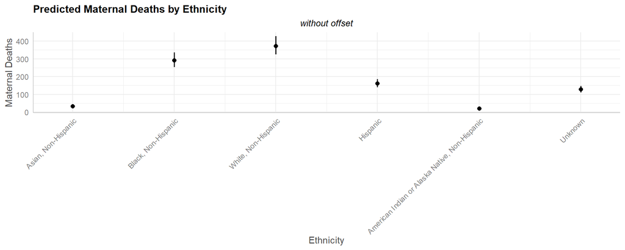

```r
pred_eth <- ggpredict(allno_glmmodel_nb, terms = "Ethnicity")
plot(pred_eth) + theme(axis.text.x = element_text(angle = 45, hjust = 1))+
 labs(
    title="Predicted Maternal Deaths by Ethnicity ",
      subtitle= "without offset", y="Maternal Deaths", x="Ethnicity"
  )+
  theme(plot.title = element_text(size = 12, face= "bold"), plot.subtitle = element_text(size = 10, face = "italic"))+ theme(plot.subtitle = element_text(hjust = 0.5))
```

```r
par(mfrow = c(1, 1))
```

Without offset, the GLMM model implies that the population with the largest number of deaths (age group 25-39) contributes most to maternal mortality rate. However, the riskiest pregnancies 40 and over women, while still being the smallest population iving birth (Sheen et al. 2018). The plot of the model with offsets shows clearly the risk to women over 40 giving birth.

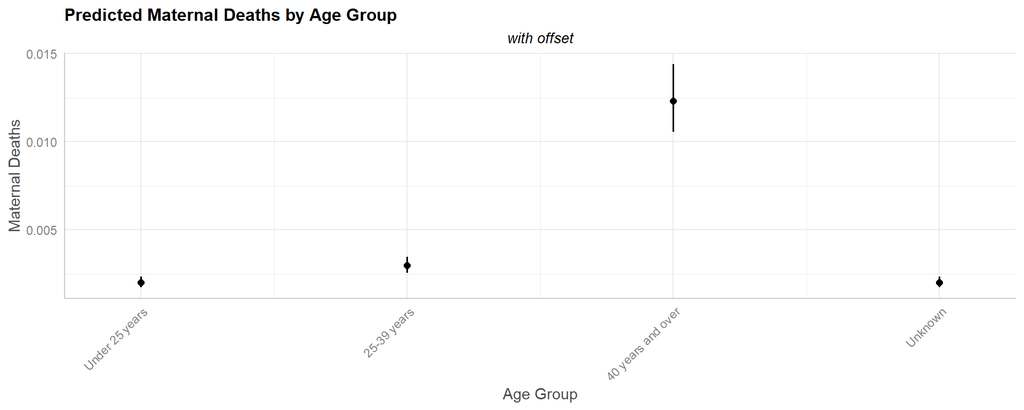

```r
par(mfrow = c(1, 2))
library(ggeffects)
library(patchwork)

pred_age1 <- ggpredict(all_glmmodel_nb, terms = "Age_Group")
plot(pred_age1) + theme(axis.text.x = element_text(angle = 45, hjust = 1))+ labs(
    title="Predicted Maternal Deaths by Age Group",
      subtitle= "with offset", y="Maternal Deaths", x="Age Group"
  )+
  theme(plot.title = element_text(size = 12, face= "bold"), plot.subtitle = element_text(size = 10, face = "italic"))+ theme(plot.subtitle = element_text(hjust = 0.5))
```

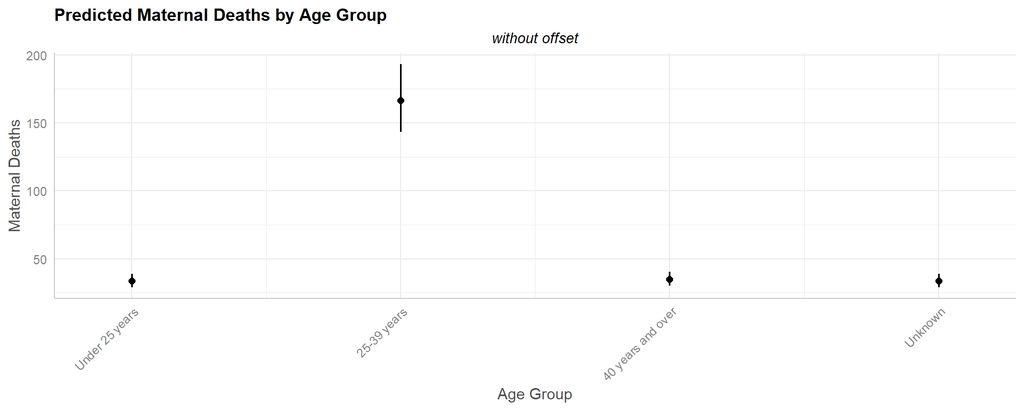

```r
pred_age <- ggpredict(allno_glmmodel_nb, terms = "Age_Group")
plot(pred_age) +  theme(axis.text.x = element_text(angle = 45, hjust = 1)) +labs(
    title="Predicted Maternal Deaths by Age Group ",
      subtitle= "without offset", y="Maternal Deaths", x="Age Group"
  )+
  theme(plot.title = element_text(size = 12, face= "bold"), plot.subtitle = element_text(size = 10, face = "italic"))+ theme(plot.subtitle = element_text(hjust = 0.5))
```

```r
par(mfrow = c(1, 1))
```

These are predictions of maternal deaths by using the models with and without offset and with predictions using the fixed effects of Ethnicity and Age group. The model with offsets shows that the women at most risk for maternal death are black and American Indian or Native Alaskan over the age of 40, though the age range increased risk to all ethnicities(MacDorman, Declercq, and Thoma 2018). Without offsets, the model focuses on the age and ethnicities with the largest populations of women that give birth, such as white women aged 25-39, followed by women of black, Hispanic, and unknown race/ethnicities. American Indian or Alaska Native are shown to have very low mortality rate because it is a smaller population overall.

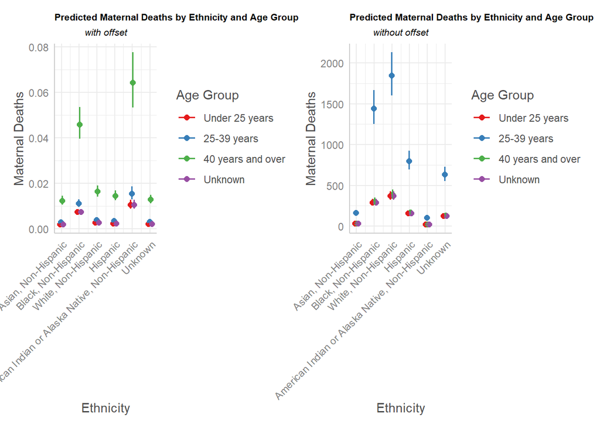

```r
library(ggeffects)
library(patchwork)
ethnicityage_effect <- ggpredict(all_glmmodel_nb, terms = c("Ethnicity","Age_Group"))

p1<-plot(ethnicityage_effect) +
  theme(axis.text.x = element_text(angle = 45, hjust = 1))+
 labs(
    title="Predicted Maternal Deaths by Ethnicity and Age Group",
      subtitle= "with offset", y="Maternal Deaths", x="Ethnicity", color = "Age Group"
  )+
  theme(plot.title = element_text(size = 8, face= "bold"), plot.subtitle = element_text(size = 8, face = "italic"))+ theme(plot.subtitle = element_text(hjust = 0.5))

ethnicityage_effect2<-ggpredict(allno_glmmodel_nb, terms = c("Ethnicity", "Age_Group"))
p2<-plot(ethnicityage_effect2) +theme(axis.text.x = element_text(angle = 45, hjust = 1))+
  labs(
    title="Predicted Maternal Deaths by Ethnicity and Age Group",
      subtitle= "without offset", y="Maternal Deaths", x="Ethnicity", color = "Age Group"
  )+
  theme(plot.title = element_text(size = 8, face= "bold"), plot.subtitle = element_text(size = 8, face = "italic"))+ theme(plot.subtitle = element_text(hjust = 0.5))

p1 + p2
```

These are predictions of maternal deaths by using the models with and without offset and with predictions using the fixed effects of Ethnicity and Dobbs Era. As shown before the non-offset model favors white women and has limitations on view of mortality of American Indian or Alaska Native women, but similarly to the offset model, post-Dobbs has lower maternal mortality.

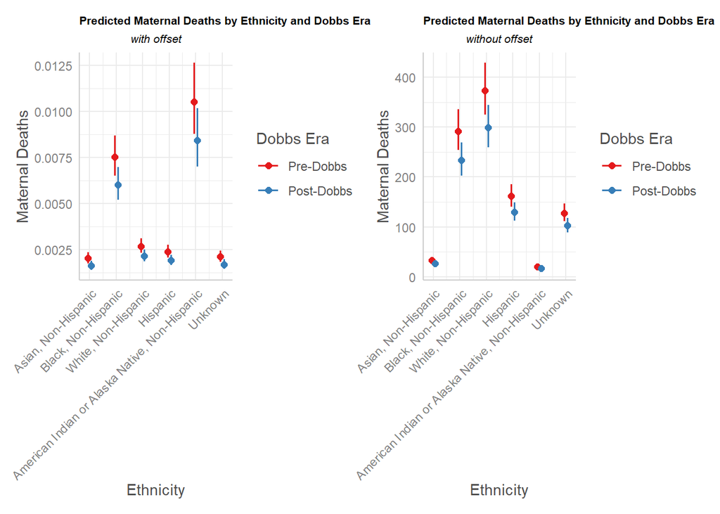

```r
#As you can see plottting without offset leads to faulty plots--no way to over look?
library(ggeffects)
library(patchwork)
ethnicitydobbs_effect <- ggpredict(all_glmmodel_nb, terms = c("Ethnicity", "Dobbs_Era"))


p1<-plot(ethnicitydobbs_effect) +
  theme(axis.text.x = element_text(angle = 45, hjust = 1))+
 labs(
    title="Predicted Maternal Deaths by Ethnicity and Dobbs Era",
      subtitle= "with offset", y="Maternal Deaths", x="Ethnicity", color = "Dobbs Era"
  )+
  theme(plot.title = element_text(size = 8, face= "bold"), plot.subtitle = element_text(size = 8, face = "italic"))+ theme(plot.subtitle = element_text(hjust = 0.5))

ethnicitydobbs_effect2<-ggpredict(allno_glmmodel_nb, terms = c("Ethnicity",  "Dobbs_Era"))
p2<-plot(ethnicitydobbs_effect2) +
theme(axis.text.x = element_text(angle = 45, hjust = 1))+
  labs(
    title="Predicted Maternal Deaths by Ethnicity and Dobbs Era",
      subtitle= "without offset", y="Maternal Deaths", x="Ethnicity", color = "Dobbs Era"
  )+
  theme(plot.title = element_text(size = 8, face = "bold"), plot.subtitle = element_text(size = 8, face = "italic")) +theme(plot.subtitle = element_text(hjust = 0.5))


p1 + p2
```

This visualization utilizes the offset model to predict maternal deaths by ethnicity and shows the prediction of American Indian or Alaska Native women having the highest maternal mortality, followed by black women. In the non-offset model, again white women are shown to have highest maternal mortality followed by black women, with unknown and Hispanic women having around same rates and lowest is the low population of American Indian and Alaskan Native.

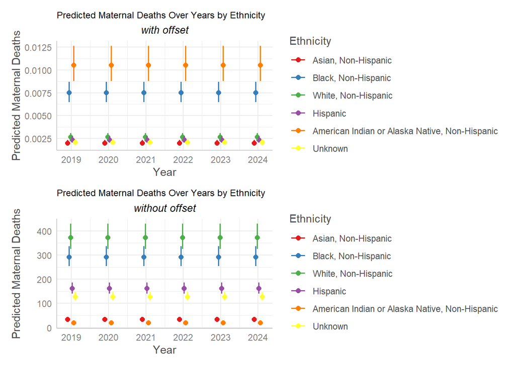

```r
library(ggplot2)
library(patchwork)

# Predicted values for Year by Ethnicity
year_eth <- ggpredict(all_glmmodel_nb, terms = c("Year", "Ethnicity"))

# Plot
p1<-plot(year_eth) +
  labs(title = "Predicted Maternal Deaths Over Years by Ethnicity",
       x = "Year", y = "Predicted Maternal Deaths", subtitle = "with offset") + theme(plot.title = element_text(size = 9), plot.subtitle = element_text(size = 10, face = "italic"))+ theme(plot.subtitle = element_text(hjust = 0.5))


# Predicted values for Year by Ethnicity
year_eth2 <- ggpredict(allno_glmmodel_nb, terms = c("Year", "Ethnicity"))

# Plot
p2<-plot(year_eth2) +
  labs(title = "Predicted Maternal Deaths Over Years by Ethnicity", subtitle= "without offset",
       x = "Year", y = "Predicted Maternal Deaths") +theme(plot.title = element_text(size = 9), plot.subtitle = element_text(size = 10, face = "italic"))+ theme(plot.subtitle = element_text(hjust = 0.5))

p1/p2
```

We find that using an offset for maternal count data per live births provided a model that may not have been the highest performing but showed clear indications of at risk groups such as American Indian women, black women, and women over 40. The non-offset model may have deceptively had better performance numbers but implied that low-risk populations had higher mortality risk due to being a larger population.

##### Limitations of this Study

- The data used is provisional and updates quarterly with both new and old counts, so further analysis may offer differing results
- The data offered counts by age group and ethnicity, but not both (i.e. maternal deaths for black women 40 and over). The inclusion of such data would give a better indication of the relationship between the two subgroups.
- Due to the Covid-19 pandemic’s impact on the healthcare system, access to regular healthcare was restricted. This likely had an impact on maternal mortality and may partially account for increased rates from around 2022.
- More variables in the dataset would offer a better picture of the predictors of maternal mortality, specifically in regards to their relationship with ethnicity. Prenatal health, healthcare access, abortion access, and other prenatal behaviors would be useful(Chinn et al. 2020).

### Conclusion

We initially hypothesized that our Dobbs Era variable would reveal changes in maternal mortality following the overturn of Roe v. Wade. However, our analysis is limited by the use of provisional data and a nationwide exposure, which may obscure more granular, state-level differences. Future models could improve on this by including State as a random effect or incorporating abortion access as a fixed effect. For example, abortion access could be categorized into three levels: extremely limited, somewhat limited, and no limitations. These additions could provide a more accurate picture of how maternal mortality has evolved in the post-Dobbs landscape.

Additionally, investigation into healthcare access for expecting mothers specific to the Covid-19 pandemic would give insight into the spike in maternal mortality rate in 2022. Given that mortality rate reaches its peak in February 2022 (months before Dobbs), it would be valuable to determine what effect is due to the pandemic in order to better evaluate the impact of the overturn of Roe v. Wade.

Regardless of these limitations, our results reaffirm a well-established and deeply concerning reality: minority women—particularly American Indian or Alaska Native women, and Black women—face significantly higher maternal mortality risks(Cusack 2024), (Tran et al. 2023).

In American Indian or Alaska Native communities, healthcare is often provided through the Indian Health Service (IHS)(Sequist et al. 2011), (Kruse et al. 2022). While this care is free, it is not always well-resourced. Health professionals within IHS are often rotated between reservations, making it difficult for patients to build long-term relationships with providers. This lack of consistency may contribute to mistrust, underreporting of symptoms, and missed clinical cues, further elevating health risks.

Similarly, Black women may struggle with issues in with the healthcare system(Tran et al. 2023). They may not be heard by their healthcare professionals and which leads to preventable complications and deaths during and after childbirth.

The higher maternal mortality for women over the age of 40 is to be expected, as geriatric pregnancies (those over age 35) are high risk(Sheen et al. 2018). However, perhaps age is only one part of the picture. Women in this age range often face many life stressors, such as caring for both children and aging parents, while also experiencing age-related health changes that may further elevate pregnancy risks.

It’s important to note that our models cannot fully explain the why behind the disparities in mortality rate between these high risk populations(Chinn et al. 2020). We are not present in the delivery room, during prenatal appointments, or throughout the postpartum period—moments where critical complications can arise. Moreover, while some datasets track prenatal care and health behaviors, they often do not follow maternal outcomes beyond live birth, limiting our ability to connect prenatal risk to maternal death.

## References

2016. *Centers for Disease Control and Prevention*. Centers for Disease Control; Prevention. https://www.cdc.gov/nchs/nvss/about_nvss.htm.

———. 2025. *Centers for Disease Control and Prevention*. Centers for Disease Control; Prevention. https://www.cdc.gov/nchs/nvss/vsrr/provisional-maternal-deaths-rates.htm.

Agresti, A. 2015. *Foundations of Linear and Generalized Linear Models*. Wiley Series in Probability and Statistics. Wiley. https://books.google.com/books?id=jlIqBgAAQBAJ.

Bates, Douglas, Martin Mächler, Ben Bolker, and Steve Walker. 2015. “Fitting Linear Mixed-Effects Models Using lme4.” *Journal of Statistical Software* 67 (1): 1–48. https://doi.org/10.18637/jss.v067.i01.

Candy, Steven G. 2000. “The Application of Generalized Linear Mixed Models to Multi-Level Sampling for Insect Population Monitoring.” *Environmental and Ecological Statistics* 7 (3): 217–38.

Chinn, Juanita J, Esther Eisenberg, Shavon Artis Dickerson, Rosalind B King, Nahida Chakhtoura, Issel Anne L Lim, Katherine L Grantz, Charisee Lamar, and Diana W Bianchi. 2020. “Maternal Mortality in the United States: Research Gaps, Opportunities, and Priorities.” *American Journal of Obstetrics and Gynecology* 223 (4): 486–92.

Compton, Sarah, and Scott L Greer. 2022. “What Overturning Roe v. Wade Means for the United States.” *Bmj*. British Medical Journal Publishing Group.

Cusack, Brynn. 2024. “Maternal Mortality in American Indian and Alaska Native Women: It Is Time to Prevent the Preventable.”

Ha, Min Jin. 2023. *R Programming in Biohealth Data Science*. Bookdown. https://bookdown.org/minjin_ha/Rprogramming/.

Hilbe, Joseph M. 2011. *Negative Binomial Regression*. Cambridge University Press.

Kruse, Gina, Victor A Lopez-Carmen, Anpotowin Jensen, Lakotah Hardie, and Thomas D Sequist. 2022. “The Indian Health Service and American Indian/Alaska Native Health Outcomes.” *Annual Review of Public Health* 43 (1): 559–76.

Lee, Youngjo, and John A Nelder. 1996. “Hierarchical Generalized Linear Models.” *Journal of the Royal Statistical Society Series B: Statistical Methodology* 58 (4): 619–56.

MacDorman, Marian F, Eugene Declercq, and Marie E Thoma. 2018. “Trends in Texas Maternal Mortality by Maternal Age, Race/Ethnicity, and Cause of Death, 2006-2015.” *Birth* 45 (2): 169–77.

McGillycuddy, Maeve, David I. Warton, Gordana Popovic, and Benjamin M. Bolker. 2025. “Parsimoniously Fitting Large Multivariate Random Effects in glmmTMB.” *Journal of Statistical Software* 112 (1): 1–19. https://doi.org/10.18637/jss.v112.i01.

Nguyen, Mike. 2020. *A Guide on Data Analysis*. Bookdown. https://bookdown.org/mike/data_analysis/.

Owili, Patrick Opiyo, Tang-Huang Lin, Miriam Adoyo Muga, and Wei-Hung Lien. 2020. “Impacts of Discriminated PM2. 5 on Global Under-Five and Maternal Mortality.” *Scientific Reports* 10 (1): 17654.

R Core Team. 2019. *R: A Language and Environment for Statistical Computing*. Vienna, Austria: R Foundation for Statistical Computing. https://www.R-project.org.

Salinas Ruı́z, Josafhat, Osval Antonio Montesinos López, Gabriela Hernández Ramı́rez, and Jose Crossa Hiriart. 2023. *Generalized Linear Mixed Models with Applications in Agriculture and Biology*. Springer Nature.

Sequist, Thomas D, Theresa Cullen, Kenneth Bernard, Shimon Shaykevich, E John Orav, and John Z Ayanian. 2011. “Trends in Quality of Care and Barriers to Improvement in the Indian Health Service.” *Journal of General Internal Medicine* 26 (5): 480–86.

Sheen, Jean-Ju, Jason D Wright, Dena Goffman, Adina R Kern-Goldberger, Whitney Booker, Zainab Siddiq, Mary E D’Alton, and Alexander M Friedman. 2018. “Maternal Age and Risk for Adverse Outcomes.” *American Journal of Obstetrics and Gynecology* 219 (4): 390–e1.

Tawiah, Kassim, Samuel Iddi, and Anani Lotsi. 2020. “On Zero-Inflated Hierarchical Poisson Models with Application to Maternal Mortality Data.” *International Journal of Mathematics and Mathematical Sciences* 2020 (1): 1407320.

Thall, Peter F. 1988. “Mixed Poisson Likelihood Regression Models for Longitudinal Interval Count Data.” *Biometrics*, 197–209.

Thompson, Jennifer A, Clemence Leyrat, Katherine L Fielding, and Richard J Hayes. 2022. “Cluster Randomised Trials with a Binary Outcome and a Small Number of Clusters: Comparison of Individual and Cluster Level Analysis Method.” *BMC Medical Research Methodology* 22 (1): 222.

Tran, Phuong, Barbara Jreij, Farideh Sistani, and Fadia T Shaya. 2023. “Disparities in Maternal Mortality.” *Journal of Clinical and Translational Science* 7 (1): e192.

Wang, Ke-Sheng, Xuefeng Liu, Muyiwa Ategbole, Xin Xie, Ying Liu, Chun Xu, Changchun Xie, and Zhanxin Sha. 2017. “Generalized Linear Mixed Model Analysis of Urban-Rural Differences in Social and Behavioral Factors for Colorectal Cancer Screening.” *Asian Pacific Journal of Cancer Prevention: APJCP* 18 (9): 2581.

Zuur, Alain F, Elena N Ieno, Neil J Walker, Anatoly A Saveliev, Graham M Smith, et al. 2009. *Mixed Effects Models and Extensions in Ecology with r*. Vol. 574. Springer.